# Practical Lab 2: Multivariate Linear Regression, Non-Parametric Models and Cross-Validation

## Part 1 (5 points)

### 1. Get the data

```python
# Import necessary libraries
import numpy as np
import pandas as pd
from sklearn import datasets
import matplotlib.pyplot as plt
import seaborn as sns

# Load the diabetes dataset
diabetes = datasets.load_diabetes(as_frame=True)
diabetes_df = diabetes.frame
diabetes_df.head()
```

|  | age | sex | bmi | bp | s1 | s2 | s3 | s4 | s5 | s6 | target |
| --- | --- | --- | --- | --- | --- | --- | --- | --- | --- | --- | --- |
| 0 | 0.038076 | 0.050680 | 0.061696 | 0.021872 | -0.044223 | -0.034821 | -0.043401 | -0.002592 | 0.019907 | -0.017646 | 151.0 |
| 1 | -0.001882 | -0.044642 | -0.051474 | -0.026328 | -0.008449 | -0.019163 | 0.074412 | -0.039493 | -0.068332 | -0.092204 | 75.0 |
| 2 | 0.085299 | 0.050680 | 0.044451 | -0.005670 | -0.045599 | -0.034194 | -0.032356 | -0.002592 | 0.002861 | -0.025930 | 141.0 |
| 3 | -0.089063 | -0.044642 | -0.011595 | -0.036656 | 0.012191 | 0.024991 | -0.036038 | 0.034309 | 0.022688 | -0.009362 | 206.0 |
| 4 | 0.005383 | -0.044642 | -0.036385 | 0.021872 | 0.003935 | 0.015596 | 0.008142 | -0.002592 | -0.031988 | -0.046641 | 135.0 |

- Each of these 10 feature variables have been mean centered and scaled by the standard deviation times the square root of n_samples (i.e. the sum of squares of each column totals 1).

### 2. Frame the Problem. Notice that the dependent variable of diabetes progression, namely "disease progression one year after baseline".

```python
y = diabetes_df['target']
```

#### Describe

```python
# basic statistics
diabetes_df.describe()
```

|  | age | sex | bmi | bp | s1 | s2 | s3 | s4 | s5 | s6 | target |
| --- | --- | --- | --- | --- | --- | --- | --- | --- | --- | --- | --- |
| count | 4.420000e+02 | 4.420000e+02 | 4.420000e+02 | 4.420000e+02 | 4.420000e+02 | 4.420000e+02 | 4.420000e+02 | 4.420000e+02 | 4.420000e+02 | 4.420000e+02 | 442.000000 |
| mean | -2.511817e-19 | 1.230790e-17 | -2.245564e-16 | -4.797570e-17 | -1.381499e-17 | 3.918434e-17 | -5.777179e-18 | -9.042540e-18 | 9.293722e-17 | 1.130318e-17 | 152.133484 |
| std | 4.761905e-02 | 4.761905e-02 | 4.761905e-02 | 4.761905e-02 | 4.761905e-02 | 4.761905e-02 | 4.761905e-02 | 4.761905e-02 | 4.761905e-02 | 4.761905e-02 | 77.093005 |
| min | -1.072256e-01 | -4.464164e-02 | -9.027530e-02 | -1.123988e-01 | -1.267807e-01 | -1.156131e-01 | -1.023071e-01 | -7.639450e-02 | -1.260971e-01 | -1.377672e-01 | 25.000000 |
| 25% | -3.729927e-02 | -4.464164e-02 | -3.422907e-02 | -3.665608e-02 | -3.424784e-02 | -3.035840e-02 | -3.511716e-02 | -3.949338e-02 | -3.324559e-02 | -3.317903e-02 | 87.000000 |
| 50% | 5.383060e-03 | -4.464164e-02 | -7.283766e-03 | -5.670422e-03 | -4.320866e-03 | -3.819065e-03 | -6.584468e-03 | -2.592262e-03 | -1.947171e-03 | -1.077698e-03 | 140.500000 |
| 75% | 3.807591e-02 | 5.068012e-02 | 3.124802e-02 | 3.564379e-02 | 2.835801e-02 | 2.984439e-02 | 2.931150e-02 | 3.430886e-02 | 3.243232e-02 | 2.791705e-02 | 211.500000 |
| max | 1.107267e-01 | 5.068012e-02 | 1.705552e-01 | 1.320436e-01 | 1.539137e-01 | 1.987880e-01 | 1.811791e-01 | 1.852344e-01 | 1.335973e-01 | 1.356118e-01 | 346.000000 |

#### Scatter plots for each columns

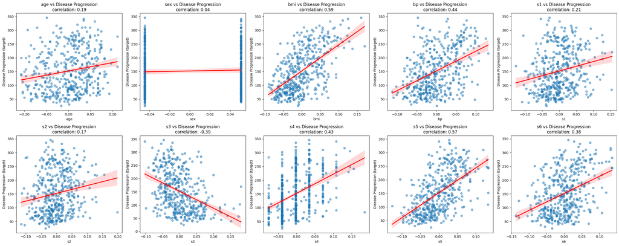

```python
plt.figure(figsize=(25, 10))
for i, col in enumerate(diabetes_df.columns[:-1]):
    plt.subplot(2, 5, i+1)
    correlation = diabetes_df[col].corr(y)

    # sns.scatterplot(x=diabetes_df[col], y=y)
    sns.regplot(x=diabetes_df[col], y=y, scatter_kws={'alpha': 0.5}, line_kws={'color': 'red'})

    plt.title(f'{col} vs Disease Progression\ncorrelation: {correlation:.2f}')
    plt.xlabel(col)
    plt.ylabel('Disease Progression (target)')

plt.tight_layout()
plt.show()
```

#### Histograms

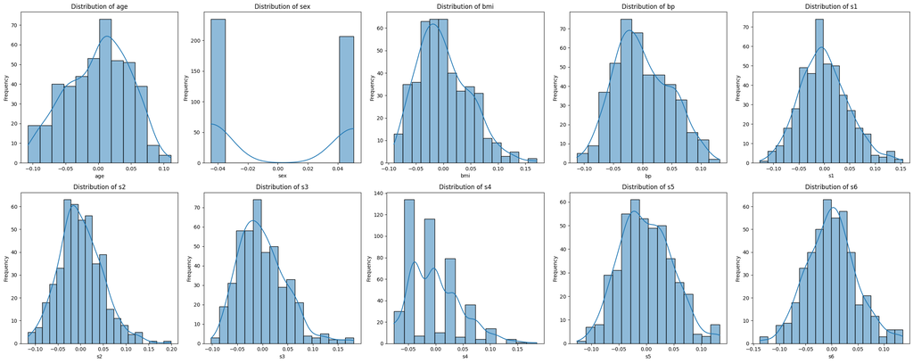

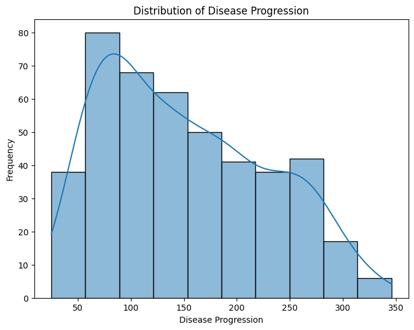

```python
plt.figure(figsize=(25, 10))
for i, col in enumerate(diabetes_df.columns[:-1]):
    plt.subplot(2, 5, i+1)
    sns.histplot(diabetes_df[col], kde=True)
    plt.title(f'Distribution of {col}')
    plt.xlabel(col)
    plt.ylabel('Frequency')

plt.tight_layout()
plt.show()

plt.figure(figsize=(8, 6))
sns.histplot(y, kde=True)
plt.title('Distribution of Disease Progression')
plt.xlabel('Disease Progression')
plt.ylabel('Frequency')
plt.show()
```

#### Correlation Matrix

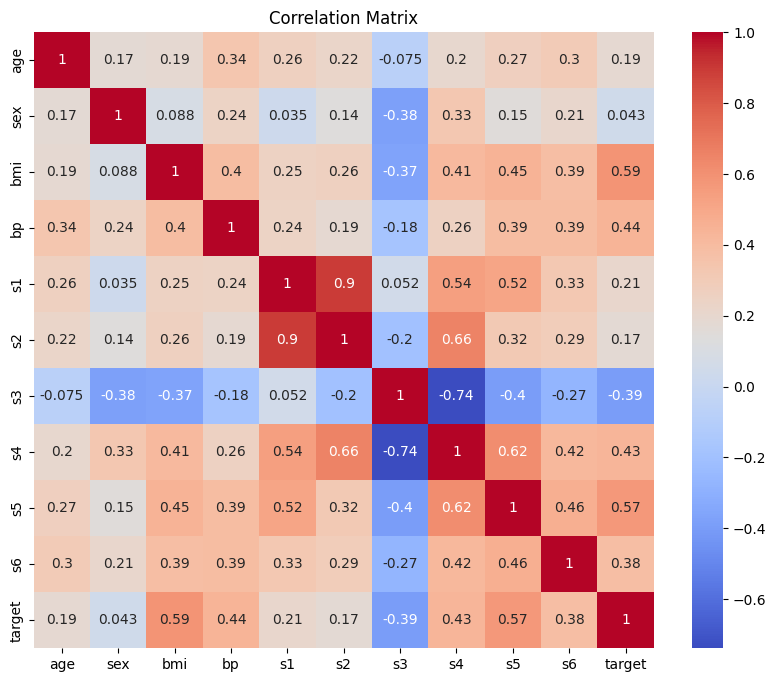

```python
correlation_matrix = diabetes_df.corr()
plt.figure(figsize=(10, 8))
sns.heatmap(correlation_matrix, annot=True, cmap='coolwarm')
plt.title('Correlation Matrix')
plt.show()
```

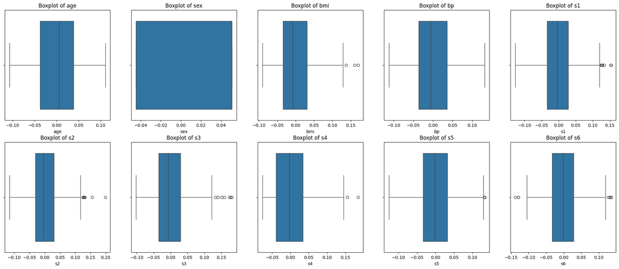

```python
# whikser plot
plt.figure(figsize=(25, 10))
for i, col in enumerate(diabetes_df.columns[:-1]):
    plt.subplot(2, 5, i+1)
    sns.boxplot(x=diabetes_df[col])
    plt.title(f'Boxplot of {col}')
    plt.xlabel(col)
```

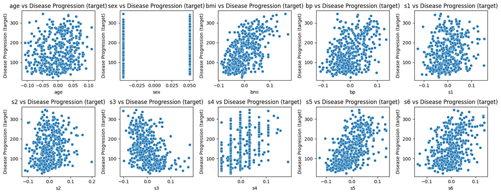

```python
plt.figure(figsize=(15, 6))
for i, col in enumerate(diabetes_df.columns[:-1]):
    plt.subplot(2, 5, i+1)
    sns.scatterplot(x=diabetes_df[col], y=y)
    plt.title(f'{col} vs Disease Progression (target)')
    plt.xlabel(col)
    plt.ylabel('Disease Progression (target)')

plt.tight_layout()
plt.show()
```

### 5. Split the dataset to a train (75%) and validation set (10%), and test set (15%).

```python
from sklearn.model_selection import train_test_split

X = diabetes_df.drop(columns=['target'])
y = diabetes_df['target']

X_train, X_temp, y_train, y_temp = train_test_split(X, y, test_size=0.25, random_state=9006413)
X_validation, X_test, y_validation, y_test = train_test_split(X_temp, y_temp, test_size=0.6, random_state=9006413)

print(f"Train size: {len(X_train)} ({len(X_train)/len(X):.2%})")
print(f"Validation size: {len(X_validation)} ({len(y_validation)/len(X):.2%})")
print(f"Test size: {len(X_test)} ({len(X_test)/len(X):.2%})")
```

```
Train size: 331 (74.89%)
Validation size: 44 (9.95%)
Test size: 67 (15.16%)
```

## Part 2 (10 points)

### 6. Models: a univariate polynomial regression on the BMI feature versus the "disease progression one year after baseline" - from degree 0 to 5 (6 models) (1.5 point)

### 7. Compare the models using the training and validation data. Construct a table summarizing the train validation results. Each model should have a separate row in the table (3 points):

1. R-Squared
2. Mean Absolute Error (MAE)
3. MAPE

```python
from sklearn.preprocessing import PolynomialFeatures
from sklearn.linear_model import LinearRegression
from sklearn.metrics import r2_score, mean_absolute_error, mean_absolute_percentage_error
```

```python
results = []
for degree in range(6):
    # set a degree 0~5
    poly = PolynomialFeatures(degree=degree)
    # fit
    X_train_poly = poly.fit_transform(X_train[['bmi']])
    # transform the training data to polynomial
    X_validation_poly = poly.transform(X_validation[['bmi']])

    # fit the model
    model = LinearRegression()
    model.fit(X_train_poly, y_train)

    # predict
    y_train_pred = model.predict(X_train_poly)
    y_validation_pred = model.predict(X_validation_poly)

    # r squared
    r2_train = r2_score(y_train, y_train_pred)
    r2_validation = r2_score(y_validation, y_validation_pred)

    # mae
    mae_train = mean_absolute_error(y_train, y_train_pred)
    mae_validation = mean_absolute_error(y_validation, y_validation_pred)

    # mape
    mape_train = mean_absolute_percentage_error(y_train, y_train_pred)
    mape_validation = mean_absolute_percentage_error(y_validation, y_validation_pred)

    results.append({
        'model': model,
        'degree': degree,
        'r2_train': r2_train,
        'r2_validation': r2_validation,
        'mae_train': mae_train,
        'mae_validation': mae_validation,
        'mape_train': mape_train,
        'mape_validation': mape_validation,
    })


results_df = pd.DataFrame(results)
results_df
```

|  | model | degree | r2_train | r2_validation | mae_train | mae_validation | mape_train | mape_validation |
| --- | --- | --- | --- | --- | --- | --- | --- | --- |
| 0 | LinearRegression() | 0 | 0.000000 | -0.014813 | 64.771625 | 73.336583 | 0.621672 | 0.612428 |
| 1 | LinearRegression() | 1 | 0.354117 | 0.068789 | 51.447398 | 64.551001 | 0.478666 | 0.546149 |
| 2 | LinearRegression() | 2 | 0.354802 | 0.070840 | 51.427751 | 64.199545 | 0.478695 | 0.540371 |
| 3 | LinearRegression() | 3 | 0.356890 | 0.064190 | 51.259108 | 63.221628 | 0.477063 | 0.527152 |
| 4 | LinearRegression() | 4 | 0.356965 | 0.065598 | 51.265892 | 62.932475 | 0.476980 | 0.523911 |
| 5 | LinearRegression() | 5 | 0.360708 | 0.077381 | 51.174224 | 62.617182 | 0.476619 | 0.521101 |

### 8. Identify the best model based on the table above.

- The highest validation R2 and lowest validation MAE or MAPE would be the best model.
- `degree = 5` is the best model.

### 9. Run the chosen model on the test set and provide results (R-Squared, MAPE, MAE) (1 point).

```python
# fixed degree 5
poly = PolynomialFeatures(degree=5)
X_test_poly = poly.fit_transform(X_test[['bmi']])

model_test = LinearRegression()
model_test.fit(X_train_poly, y_train)

# use the test data to evaluate the model_test
y_test_pred = model_test.predict(X_test_poly)

r2_test = r2_score(y_test, y_test_pred)
mae_test = mean_absolute_error(y_test, y_test_pred)
mape_test = mean_absolute_percentage_error(y_test, y_test_pred)

print(f"R2 Test: {r2_test:.2f}")
print(f"MAE Test: {mae_test:.2f}")
print(f"MAPE Test: {mape_test:.2f}")
```

```
R2 Test: 0.48
MAE Test: 42.97
MAPE Test: 0.33
```

### 10. Plot a graph of the train, validation and test data points, and the fit of the chosen model over each of them (1 point).

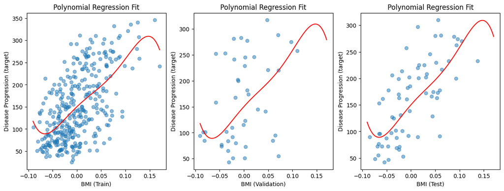

```python
# Plot the x-axis range
x_range = pd.DataFrame(np.linspace(diabetes_df['bmi'].min(), diabetes_df['bmi'].max(), 100), columns=['bmi'])
# transform the x_range to polynomial features
x_range_poly = poly.transform(x_range)
model_train_5 = results_df[results_df['degree'] == 5]['model'].values[0]
y_range_pred = model_train_5.predict(x_range_poly)

plt.figure(figsize=(15, 5))
plt.subplot(1, 3, 1)
plt.scatter(X_train[['bmi']], y_train, label='Train', alpha=0.5)
plt.plot(x_range, y_range_pred, color='red', label='Polynomial Fit')
plt.title('Polynomial Regression Fit')
plt.xlabel('BMI (Train)')
plt.ylabel('Disease Progression (target)')

plt.subplot(1, 3, 2)
plt.scatter(X_validation[['bmi']], y_validation, label='Validation', alpha=0.5)
plt.plot(x_range, y_range_pred, color='red', label='Polynomial Fit')
plt.title('Polynomial Regression Fit')
plt.xlabel('BMI (Validation)')
plt.ylabel('Disease Progression (target)')

plt.subplot(1, 3, 3)
plt.scatter(X_test[['bmi']], y_test, label='Test', alpha=0.5)
plt.plot(x_range, y_range_pred, color='red', label='Polynomial Fit')
plt.title('Polynomial Regression Fit')
plt.xlabel('BMI (Test)')
plt.ylabel('Disease Progression (target)')
plt.show()
```

### 11. Write down the equation of the best model (with a two decimal digit precision, assuming it's sufficient) (1 point).

```python
coefficients = model_train_5.coef_
intercept = model_train_5.intercept_

# Print the equation with all terms
equation = f"y = {intercept:.2f}"
for i in range(1, len(coefficients)):
    term = f" + {coefficients[i]:.2f} * bmi^{i}" if i > 1 else f" + {coefficients[i]:.2f} * bmi"
    equation += term

print(equation)
```

```
y = 150.15 + 1045.17 * bmi + -3791.31 * bmi^2 + -1636.58 * bmi^3 + 928137.99 * bmi^4 + -4964208.04 * bmi^5
```

### 12. Calculate the expected diabetes progression for a BMI value of your choice using `model.perdict()` for that value (0.5 point).

```python
bmi_value = 0.044451 # row 3
bmi_value_df = pd.DataFrame([[bmi_value]], columns=['bmi'])
prediction = model_train_5.predict(poly.transform(bmi_value_df))
print(f"Predicted disease progression for BMI={bmi_value}: {prediction[0]:.2f}")

# Actual value for comparison
print(f"Actual disease progression for BMI={bmi_value}: {diabetes_df.iloc[2]['target']:.2f}")
```

```
Predicted disease progression for BMI=0.044451: 191.74
Actual disease progression for BMI=0.044451: 141.00
```

### 13. How many trainable parameters are we fitting for each of the models? Explain these values. One way is to use sklearn function `get_feature_names_out()`(1 point)

```python
for i in range(6):
    poly = PolynomialFeatures(degree=i)
    X_train_poly = poly.fit_transform(X_train[['bmi']])
    # insert into results_df
    results_df.loc[results_df['degree'] == i, 'num_features'] = X_train_poly.shape[1]
    results_df.loc[results_df['degree'] == i, 'feature_names'] = ', '.join(poly.get_feature_names_out())

results_df
```

|  | model | degree | r2_train | r2_validation | mae_train | mae_validation | mape_train | mape_validation | num_features | feature_names |
| --- | --- | --- | --- | --- | --- | --- | --- | --- | --- | --- |
| 0 | LinearRegression() | 0 | 0.000000 | -0.014813 | 64.771625 | 73.336583 | 0.621672 | 0.612428 | 1.0 | 1 |
| 1 | LinearRegression() | 1 | 0.354117 | 0.068789 | 51.447398 | 64.551001 | 0.478666 | 0.546149 | 2.0 | 1, bmi |
| 2 | LinearRegression() | 2 | 0.354802 | 0.070840 | 51.427751 | 64.199545 | 0.478695 | 0.540371 | 3.0 | 1, bmi, bmi^2 |
| 3 | LinearRegression() | 3 | 0.356890 | 0.064190 | 51.259108 | 63.221628 | 0.477063 | 0.527152 | 4.0 | 1, bmi, bmi^2, bmi^3 |
| 4 | LinearRegression() | 4 | 0.356965 | 0.065598 | 51.265892 | 62.932475 | 0.476980 | 0.523911 | 5.0 | 1, bmi, bmi^2, bmi^3, bmi^4 |
| 5 | LinearRegression() | 5 | 0.360708 | 0.077381 | 51.174224 | 62.617182 | 0.476619 | 0.521101 | 6.0 | 1, bmi, bmi^2, bmi^3, bmi^4, bmi^5 |

- For a polynomial regression with degree *d*, the model learns coefficients for terms like $[1, x, x^2, \ldots, x^d]$

### 14. Provide a conclusion section. In particular, do a deep dive on where the model fails, and add a short section in the conclusions that describes the model limitations. This should be in addition to summarizing it performance. (1 point).

- Using only BMI as a feature limits the model's ability to capture interactions, `s5 (ltg, possibly log of serum triglycerides level)` also showed strong correlations with the target variable.
- BMI represent right-skewed distribution, also, polynomial regression is sensitive to outliers, may not accurate enough.
- Perhaps kNN may be more suitable for prediction based on probability and using multiple features.
- The degree-5 polynomial model, may be overfitting the training data.
- Linear regression assumes linearity may not hold for all datasets.

## Part 3 (5 points)

### 1. Two polynomial models (degrees >1, of your choice)

#### Campare the models with different feature and degree =5,6

```python
results_multi = []
for col in diabetes_df.columns:
    if col == 'target' or col == 'bmi': continue
    for degree in [5,6]:
        # set a degree 0~5
        poly = PolynomialFeatures(degree=degree)
        # fit
        X_train_poly = poly.fit_transform(X_train[[col]])
        # transform the training data to polynomial
        X_validation_poly = poly.transform(X_validation[[col]])

        # fit the model
        model = LinearRegression()
        model.fit(X_train_poly, y_train)

        # predict
        y_train_pred = model.predict(X_train_poly)
        y_validation_pred = model.predict(X_validation_poly)

        # r squared
        r2_train = r2_score(y_train, y_train_pred)
        r2_validation = r2_score(y_validation, y_validation_pred)

        # mae
        mae_train = mean_absolute_error(y_train, y_train_pred)
        mae_validation = mean_absolute_error(y_validation, y_validation_pred)

        # mape
        mape_train = mean_absolute_percentage_error(y_train, y_train_pred)
        mape_validation = mean_absolute_percentage_error(y_validation, y_validation_pred)

        results_multi.append({
            'model': model,
            'feature': col,
            'degree': degree,
            'r2_train': r2_train,
            'r2_validation': r2_validation,
            'mae_train': mae_train,
            'mae_validation': mae_validation,
            'mape_train': mape_train,
            'mape_validation': mape_validation,
        })

results_multi_df = pd.DataFrame(results_multi)
results_multi_df
```

|  | model | feature | degree | r2_train | r2_validation | mae_train | mae_validation | mape_train | mape_validation |
| --- | --- | --- | --- | --- | --- | --- | --- | --- | --- |
| 0 | LinearRegression() | age | 5 | 0.037767 | -0.032738 | 63.447113 | 74.552327 | 0.602097 | 0.608242 |
| 1 | LinearRegression() | age | 6 | 0.038077 | -0.019343 | 63.478753 | 74.057768 | 0.601884 | 0.603920 |
| 2 | LinearRegression() | sex | 5 | 0.001925 | -0.021712 | 64.777497 | 73.812855 | 0.621523 | 0.617957 |
| 3 | LinearRegression() | sex | 6 | 0.001925 | -0.021713 | 64.777356 | 73.812678 | 0.621518 | 0.617952 |
| 4 | LinearRegression() | bp | 5 | 0.173406 | 0.137292 | 57.271494 | 65.377176 | 0.545578 | 0.491323 |
| 5 | LinearRegression() | bp | 6 | 0.173565 | 0.139466 | 57.279375 | 65.127472 | 0.545004 | 0.488426 |
| 6 | LinearRegression() | s1 | 5 | 0.051500 | 0.024864 | 62.798519 | 70.426004 | 0.593632 | 0.571115 |
| 7 | LinearRegression() | s1 | 6 | 0.054022 | -0.003474 | 62.658078 | 71.552353 | 0.592410 | 0.576049 |
| 8 | LinearRegression() | s2 | 5 | 0.039826 | 0.003198 | 63.220684 | 70.919217 | 0.595953 | 0.581759 |
| 9 | LinearRegression() | s2 | 6 | 0.040548 | 0.019506 | 63.165197 | 70.334562 | 0.594415 | 0.581068 |
| 10 | LinearRegression() | s3 | 5 | 0.146290 | 0.214922 | 58.504164 | 63.872489 | 0.543136 | 0.530337 |
| 11 | LinearRegression() | s3 | 6 | 0.151703 | 0.217316 | 58.208810 | 63.875551 | 0.539186 | 0.531369 |
| 12 | LinearRegression() | s4 | 5 | 0.197828 | 0.278093 | 57.221670 | 57.839999 | 0.525226 | 0.475398 |
| 13 | LinearRegression() | s4 | 6 | 0.201894 | 0.262181 | 57.163749 | 58.289176 | 0.523543 | 0.479750 |
| 14 | LinearRegression() | s5 | 5 | 0.338645 | 0.388406 | 50.548913 | 51.109640 | 0.455986 | 0.407174 |
| 15 | LinearRegression() | s5 | 6 | 0.339366 | 0.390641 | 50.360681 | 51.247492 | 0.454250 | 0.405365 |
| 16 | LinearRegression() | s6 | 5 | 0.127822 | 0.140431 | 59.843225 | 67.869869 | 0.569241 | 0.560250 |
| 17 | LinearRegression() | s6 | 6 | 0.132013 | 0.138252 | 59.947776 | 67.807950 | 0.569155 | 0.561660 |

#### Identify the best model

- Except the bmi, `feature = s5 and degree = 6` has the highest $R^2$ and lowest MAPE
- However higher-degree polynomials may overfit the training data, the improvement from degree 5 to degree 6 is small. A simpler model `degree = 5` might be preferred!

#### Run the chosen model on test set

```python
# fixed degree 5
poly = PolynomialFeatures(degree=5)
X_test_poly = poly.fit_transform(X_test[['s5']])
X_train_poly_s5 = poly.fit_transform(X_train[['s5']])

# fit the model
model_test_s5 = LinearRegression()
model_test_s5.fit(X_train_poly_s5, y_train)

# use the test data to evaluate the model_test
y_test_pred = model_test_s5.predict(X_test_poly)

# calculate the metrics
r2_test = r2_score(y_test, y_test_pred)
mae_test = mean_absolute_error(y_test, y_test_pred)
mape_test = mean_absolute_percentage_error(y_test, y_test_pred)

print(f"R2 Test: {r2_test:.2f}")
print(f"MAE Test: {mae_test:.2f}")
print(f"MAPE Test: {mape_test:.2f}")
```

```
R2 Test: 0.32
MAE Test: 48.77
MAPE Test: 0.39
```

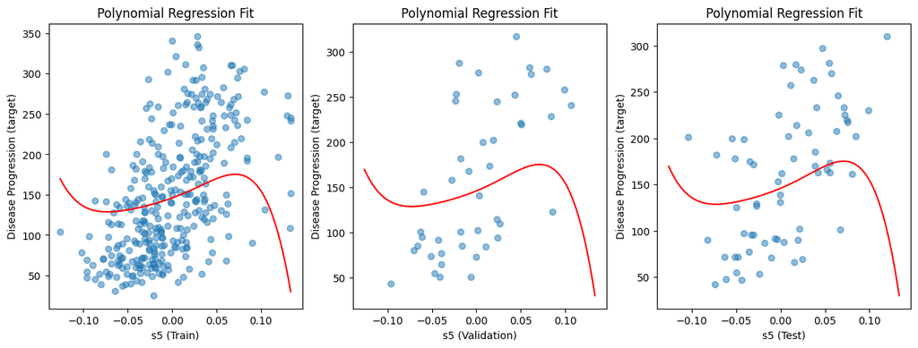

```python
# plot the polynomial fit
x_range = pd.DataFrame(np.linspace(diabetes_df['s5'].min(), diabetes_df['s5'].max(), 100), columns=['s5'])
# transform the x_range to polynomial features
x_range_poly = poly.transform(x_range)
# choose the model with degree 5
model_train_s5 = results_multi_df[results_multi_df['degree'] == 5]['model'].values[0]
# predict the y_range
y_range_pred = model_train_s5.predict(x_range_poly)

plt.figure(figsize=(15, 5))
plt.subplot(1, 3, 1)
plt.scatter(X_train[['s5']], y_train, label='Train', alpha=0.5)
plt.plot(x_range, y_range_pred, color='red', label='Polynomial Fit')
plt.title('Polynomial Regression Fit')
plt.xlabel('s5 (Train)')
plt.ylabel('Disease Progression (target)')


plt.subplot(1, 3, 2)
plt.scatter(X_validation[['s5']], y_validation, label='Validation', alpha=0.5)
plt.plot(x_range, y_range_pred, color='red', label='Polynomial Fit')
plt.title('Polynomial Regression Fit')
plt.xlabel('s5 (Validation)')
plt.ylabel('Disease Progression (target)')

plt.subplot(1, 3, 3)
plt.scatter(X_test[['s5']], y_test, label='Test', alpha=0.5)
plt.plot(x_range, y_range_pred, color='red', label='Polynomial Fit')
plt.title('Polynomial Regression Fit')
plt.xlabel('s5 (Test)')
plt.ylabel('Disease Progression (target)')
plt.show()
```

#### Equation

```python
coefficients = model_train_s5.coef_
intercept = model_train_s5.intercept_

# Print the equation with all terms
equation = f"y = {intercept:.2f}"
for i in range(1, len(coefficients)):
    term = f" + {coefficients[i]:.2f} * bmi^{i}" if i > 1 else f" + {coefficients[i]:.2f} * bmi"
    equation += term

print(equation)
```

```
y = 145.94 + 404.42 * bmi + 2479.28 * bmi^2 + 770.43 * bmi^3 + -254548.87 * bmi^4 + -3172017.04 * bmi^5
```

#### Calculate the expected diabestes progression

```python
s5_value = 0.002861 # row 3
s5_value_df = pd.DataFrame([[s5_value]], columns=['s5'])
prediction = model_train_s5.predict(poly.transform(s5_value_df))
print(f"Predicted disease progression for s5={s5_value}: {prediction[0]:.2f}")

# Actual value for comparison
print(f"Actual disease progression for s5={s5_value}: {y[2]}")
```

```
Predicted disease progression for s5=0.002861: 147.12
Actual disease progression for s5=0.002861: 141.0
```

#### How many trainable parameters

```python
poly = PolynomialFeatures(degree=5)
X_train_poly = poly.fit_transform(X_train[['s5']])
print(f"Number of features: {X_train_poly.shape[1]}")  # This equals the number of trainable parameters
print(poly.get_feature_names_out())
```

```
Number of features: 6
['1' 's5' 's5^2' 's5^3' 's5^4' 's5^5']
```

### 2. Two decision trees (e.g. consider changing the `max_depth` hyperparameter)

#### Campare the models

```python
from sklearn.tree import DecisionTreeRegressor

results_dt = []
for depth in range(1, 1000):
    dt_model = DecisionTreeRegressor(max_depth=depth, random_state=9006413)
    dt_model.fit(X_train, y_train)

    # predict on training and validation sets
    y_train_pred = dt_model.predict(X_train)
    y_validation_pred = dt_model.predict(X_validation)

    # calculate the metrics
    r2_train = r2_score(y_train, y_train_pred)
    r2_validation = r2_score(y_validation, y_validation_pred)
    mae_train = mean_absolute_error(y_train, y_train_pred)
    mae_validation = mean_absolute_error(y_validation, y_validation_pred)
    mape_train = mean_absolute_percentage_error(y_train, y_train_pred)
    mape_validation = mean_absolute_percentage_error(y_validation, y_validation_pred)

    results_dt.append({
        'model': dt_model,
        'depth': depth,
        'r2_train': r2_train,
        'r2_validation': r2_validation,
        'mae_train': mae_train,
        'mae_validation': mae_validation,
        'mape_train': mape_train,
        'mape_validation': mape_validation,
    })

results_dt_df = pd.DataFrame(results_dt)

# filter r2_validation < 0
filtered_results_dt_df = results_dt_df[results_dt_df['r2_validation'] > 0].sort_values('r2_validation', ascending=False)
filtered_results_dt_df
```

|  | model | depth | r2_train | r2_validation | mae_train | mae_validation | mape_train | mape_validation |
| --- | --- | --- | --- | --- | --- | --- | --- | --- |
| 3 | DecisionTreeRegressor(max_depth=4, random_stat... | 4 | 0.603071 | 0.312585 | 38.711104 | 54.699243 | 0.354270 | 0.402979 |
| 2 | DecisionTreeRegressor(max_depth=3, random_stat... | 3 | 0.532991 | 0.286117 | 42.960861 | 56.178472 | 0.389787 | 0.423825 |
| 4 | DecisionTreeRegressor(max_depth=5, random_stat... | 5 | 0.674108 | 0.246261 | 33.717270 | 53.201982 | 0.316444 | 0.400380 |
| 1 | DecisionTreeRegressor(max_depth=2, random_stat... | 2 | 0.442010 | 0.234081 | 46.971870 | 57.661592 | 0.423085 | 0.446201 |
| 5 | DecisionTreeRegressor(max_depth=6, random_stat... | 6 | 0.754219 | 0.104083 | 28.061799 | 59.469499 | 0.262727 | 0.431553 |

#### Identify the best model

- `max_depth = 4` is identified as the best-performing model in the data, with high $R^2$ value and low MAE and MAPE scores on the validation set.

#### Run the chosen model on test set

```python
best_dt_model = filtered_results_dt_df['model'].values[0]

# predict on test set
y_test_pred = best_dt_model.predict(X_test)

# calculate the metrics
r2_test = r2_score(y_test, y_test_pred)
mae_test = mean_absolute_error(y_test, y_test_pred)
mape_test = mean_absolute_percentage_error(y_test, y_test_pred)

print(f"R2 Test: {r2_test:.2f}")
print(f"MAE Test: {mae_test:.2f}")
print(f"MAPE Test: {mape_test:.2f}")
```

```
R2 Test: 0.54
MAE Test: 40.51
MAPE Test: 0.33
```

#### Plot a graph of the train, validation and test data points, and the fit of the chosen model over each of them

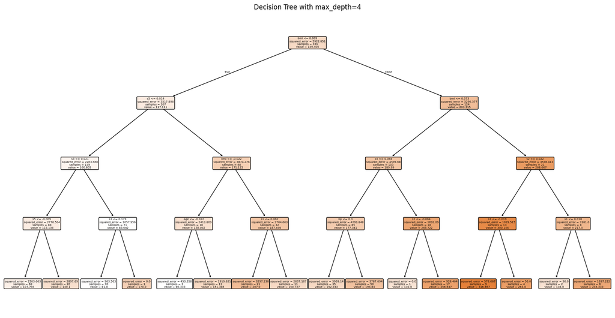

```python
from sklearn.tree import plot_tree
import matplotlib.pyplot as plt

plt.figure(figsize=(20, 10))
plot_tree(best_dt_model, filled=True, feature_names=X.columns, rounded=True)
plt.title('Decision Tree with max_depth=4')
plt.show()
```

#### Equation

- no equation in decsion tree

#### Calculate the expected diabestes progression

```python
# row 3
row_3 = diabetes_df.iloc[[2]].drop(columns=['target'])

# predict the disease progression
prediction = best_dt_model.predict(row_3)
print(f"Predicted diabetes progression: {prediction[0]:.2f}")

# Actual value for comparison
actual_progression = diabetes_df.iloc[2]['target']
print(f"Actual diabetes progression: {actual_progression:.2f}")
```

```
Predicted diabetes progression: 152.34
Actual diabetes progression: 141.00
```

#### How many trainable parameter

```python
# Get the number of nodes in the tree
n_nodes = best_dt_model.tree_.node_count
print(f"Number of nodes: {n_nodes}")
```

```
Number of nodes: 31
```

#### Conclusion

- Although `depth = 4` is a relatively good model, however, the model has higher r2_train and lower mae_train, and also r2_validation and mae_validation are relatively poor, which is a typical `overfitting` phenomenon.

### 3. Two kNNs

#### Campare the models

```python
from sklearn.neighbors import KNeighborsRegressor

results_knn = []
for n_neighbor in range(2,100):
    knn_model = KNeighborsRegressor(n_neighbors=n_neighbor)
    knn_model.fit(X_train, y_train)

    # predict
    y_train_pred = knn_model.predict(X_train)
    y_validation_pred = knn_model.predict(X_validation)

    # calculate the metrics
    r2_train = r2_score(y_train, y_train_pred)
    r2_validation = r2_score(y_validation, y_validation_pred)
    mae_train = mean_absolute_error(y_train, y_train_pred)
    mae_validation = mean_absolute_error(y_validation, y_validation_pred)
    mape_train = mean_absolute_percentage_error(y_train, y_train_pred)
    mape_validation = mean_absolute_percentage_error(y_validation, y_validation_pred)

    results_knn.append({
        'model': knn_model,
        'n_neighbors': n_neighbor,
        'r2_train': r2_train,
        'r2_validation': r2_validation,
        'mae_train': mae_train,
        'mae_validation': mae_validation,
        'mape_train': mape_train,
        'mape_validation': mape_validation,
    })

results_knn_df = pd.DataFrame(results_knn).sort_values('r2_validation', ascending=False)
results_knn_df
```

|  | model | n_neighbors | r2_train | r2_validation | mae_train | mae_validation | mape_train | mape_validation |
| --- | --- | --- | --- | --- | --- | --- | --- | --- |
| 17 | KNeighborsRegressor(n_neighbors=19) | 19 | 0.465867 | 0.415075 | 45.494514 | 53.613636 | 0.413159 | 0.402104 |
| 21 | KNeighborsRegressor(n_neighbors=23) | 23 | 0.458418 | 0.411134 | 46.246946 | 54.094862 | 0.417549 | 0.412876 |
| 18 | KNeighborsRegressor(n_neighbors=20) | 20 | 0.459334 | 0.410920 | 45.929154 | 53.972727 | 0.417617 | 0.406199 |
| 16 | KNeighborsRegressor(n_neighbors=18) | 18 | 0.471651 | 0.410070 | 45.194361 | 53.693182 | 0.410396 | 0.404578 |
| 20 | KNeighborsRegressor(n_neighbors=22) | 22 | 0.461237 | 0.408767 | 46.078824 | 54.387397 | 0.416887 | 0.415248 |
| ... | ... | ... | ... | ... | ... | ... | ... | ... |
| 2 | KNeighborsRegressor(n_neighbors=4) | 4 | 0.606421 | 0.284003 | 37.389728 | 56.948864 | 0.335057 | 0.402929 |
| 5 | KNeighborsRegressor(n_neighbors=7) | 7 | 0.530336 | 0.260990 | 41.874407 | 59.321429 | 0.372024 | 0.416498 |
| 1 | KNeighborsRegressor(n_neighbors=3) | 3 | 0.650983 | 0.259860 | 34.391742 | 55.992424 | 0.301833 | 0.399508 |
| 6 | KNeighborsRegressor(n_neighbors=8) | 8 | 0.527148 | 0.258484 | 42.223565 | 59.517045 | 0.377475 | 0.426698 |
| 0 | KNeighborsRegressor(n_neighbors=2) | 2 | 0.739829 | 0.253736 | 29.971299 | 53.136364 | 0.261077 | 0.367078 |

98 rows × 8 columns

#### Run the chosen model on test set

```python
best_knn_model = results_knn_df['model'].values[0]

# predict on test set
y_test_pred = best_knn_model.predict(X_test)

# calculate the metrics
r2_test = r2_score(y_test, y_test_pred)
mae_test = mean_absolute_error(y_test, y_test_pred)
mape_test = mean_absolute_percentage_error(y_test, y_test_pred)

print(f"R2 Test: {r2_test:.2f}")
print(f"MAE Test: {mae_test:.2f}")
print(f"MAPE Test: {mape_test:.2f}")
```

```
R2 Test: 0.60
MAE Test: 36.75
MAPE Test: 0.29
```

#### Plot a graph of the train, validation and test data points, and the fit of the chosen model over each of them

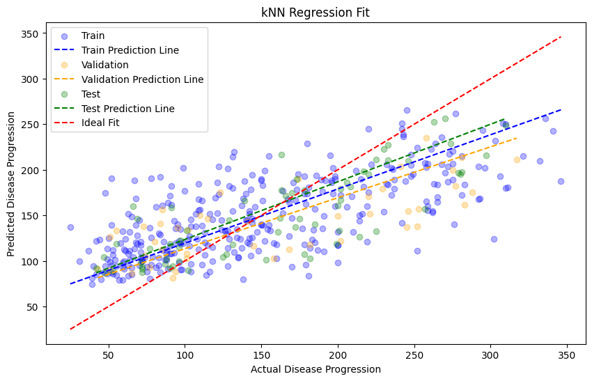

```python
plt.figure(figsize=(10, 6))

y_train_pred = best_knn_model.predict(X_train)
y_validation_pred = best_knn_model.predict(X_validation)
y_test_pred = best_knn_model.predict(X_test)

# Scatter plot for training data
plt.scatter(y_train, y_train_pred, alpha=0.3, label='Train', color='blue')
# plot the line of training data
plt.plot([y_train.min(), y_train.max()],
         [y_train_pred.min(), y_train_pred.max()],
         color='blue', linestyle='--', label='Train Prediction Line')

# Scatter plot for validation data
plt.scatter(y_validation, y_validation_pred, alpha=0.3, label='Validation', color='orange')
# plot the line of validation data
plt.plot([y_validation.min(), y_validation.max()],
        [y_validation_pred.min(), y_validation_pred.max()],
        color='orange', linestyle='--', label='Validation Prediction Line')


# Scatter plot for test data
plt.scatter(y_test, y_test_pred, alpha=0.3, label='Test', color='green')
# plot the line of test data
plt.plot([y_test.min(), y_test.max()],
        [y_test_pred.min(), y_test_pred.max()],
        color='green', linestyle='--', label='Test Prediction Line')

# Plot the line y=x for reference : Ideal Fit
plt.plot([min(y_train.min(), y_validation.min(), y_test.min()),
          max(y_train.max(), y_validation.max(), y_test.max())],
         [min(y_train.min(), y_validation.min(), y_test.min()),
          max(y_train.max(), y_validation.max(), y_test.max())],
         color='red', linestyle='--', label='Ideal Fit')

plt.title('kNN Regression Fit')
plt.xlabel('Actual Disease Progression')
plt.ylabel('Predicted Disease Progression')
plt.legend()
plt.show()
```

#### Equation

- no equation in knn model

#### Calculate the expected diabestes progression

```python
# row 3
row_3 = diabetes_df.iloc[[2]].drop(columns=['target'])

# predict the disease progression
prediction = best_knn_model.predict(row_3)
print(f"Predicted diabetes progression: {prediction[0]:.2f}")

# Actual value for comparison
actual_progression = diabetes_df.iloc[2]['target']
print(f"Actual diabetes progression: {actual_progression:.2f}")
```

```
Predicted diabetes progression: 143.21
Actual diabetes progression: 141.00
```

#### How many trainable parameter

- There are not trainable parameters in the traditional sense in knn model
- Each data point in the training set is used to make predictions for new data points

#### Conclusion

- This knn model is the best fit for this dataset of the models
- knn can be computationally expensive, especially with large datasets
- knn is sensitive to the size of the input features. Since all features were standardized, this issue was mitigated
- As the number of features increases, the effectiveness of kNN can decrease
- knn models are less interpretable than linear models